# Primary Cesarean delivery rates, 2016-2q2019

> I need to move the doctor stuff at the bottom to the deliveries analysis, I think.

By **Christian McDonald**, Assistant Professor of Practice  
School of Journalism, Moody College of Communication  
University of Texas at Austin

This is an analysis of the Primary Cesarean Delivery Rate, Uncomplicated, as defined by [AHRQ IQI 33](https://www.qualityindicators.ahrq.gov/Downloads/Modules/IQI/V2019/TechSpecs/IQI_33_Primary_Cesarean_Delivery_Rate_Uncomplicated.pdf) in 2019:

“First-time Cesarean deliveries without a hysterotomy procedure per 1,000 deliveries. Excludes deliveries with complications (abnormal presentation, preterm delivery, fetal death, multiple gestation diagnoses, or breech procedure).”

This analysis has enough results to avoid defining as “per 1,000 deliveries”. I use a simple rate: Primary Cesarean / All uncomplicated deliveries.

## AHRQ definition

### Numerator

Discharges, among cases meeting the inclusion and exclusion rules for the denominator, with either:

- MS-DRG codes for Cesarean delivery (PRCSE2G* ) without any-listed ICD-10-PCS procedure codes for hysterotomy (PRCSE2P* ) or
- any-listed ICD-10-PCS procedure codes for Cesarean delivery (PRCSECP* ) without any-listed ICD- 10-PCS procedure codes for hysterotomy (PRCSE2P* ).

### Denominator

All deliveries, identified by any-listed ICD-10-CM diagnosis code for outcome of delivery (DELOCMD).

Exclude cases:

- with any-listed ICD-10-CM diagnosis codes for abnormal presentation, preterm, fetal death, or multiple gestation (Appendix A: PRCSECD)
- with any-listed ICD-10-CM diagnosis codes for previous Cesarean delivery (PRVBACD* )
- with missing gender (SEX=missing), age (AGE=missing), quarter (DQTR=missing), year (YEAR=missing) or principal diagnosis (DX1=missing)

```r
library(tidyverse)
library(janitor)
library(DT)
```

## Import of deliveries

I start here with “All deliveries, identified by any-listed ICD-10-CM diagnosis code for outcome of delivery (DELOCMD)”. This was processed in `01-process-loop`.

```r
# set test flag to FALSE to run production data
test_flag <- F

### test data
path_test <- "data-test/ahrq_del_all_loop_test.rds"

### production data
path_prod <- "data-processed/ahrq_del_all.rds"

### import based on flag
if (test_flag == T) del <- read_rds(path_test) else del <- read_rds(path_prod)

del %>% nrow()
```

```
## [1] 1271158
```

## Set up various processing lists

These are lists from the IQI 33 reference used for filtering and such. See 01-process-lists for definitions.

```r
# diagnostic columns
diag_cols <- read_rds("procedures-lists/cols_diag.rds") %>% .$diag

# surgical procedure columns
surg_cols <- read_rds("procedures-lists/cols_surg.rds") %>% .$surg

# appendix a complications list
prcsecd_list <- read_rds("procedures-lists/ahrq_prcsecd.rds") %>% .$prcsecd

# Cesarean delivery MS-DRG codes, updated
prcse2g_v2_list <- read_rds("procedures-lists/ahrq_prcse2g_v2.rds") %>% .$prcse2g

# Hysterotomy procedure codes: (PRCSE2P)
prcse2p_list <- read_rds("procedures-lists/ahrq_prcse2p.rds") %>% .$prcse2p

# Previous Cesarean delivery diagnosis codes: (PRVBACD)
prvbacd_list <- read_rds("procedures-lists/ahrq_prvbacd.rds") %>% .$prvbacd
```

## Filter deliveries to set denominator

### Filter out complicated deliveries

Start by filtering out rows “with any-listed ICD-10-CM diagnosis codes for abnormal presentation, preterm, fetal death, or multiple gestation (Appendix A: PRCSECD)”.

```r
del_ucmp <- del %>%
  filter_at(
    vars(all_of(diag_cols)),
    all_vars(
      !(. %in% prcsecd_list)
    )
  )

del_ucmp %>% nrow()
```

```
## [1] 1147410
```

### Filter out previous Cesarean deliveries

For this analysis, I need to additionally exclude outcomes “with any-listed ICD-10-CM diagnosis codes for previous Cesarean delivery (PRVBACD)”. This prvbacd_list comes from the AHRQ specification.

```r
del_nprv <- del_ucmp %>%
  filter_at(
    vars(all_of(diag_cols)),
    all_vars(
      !(. %in% prvbacd_list)
    )
  )

del_nprv %>% nrow()
```

```
## [1] 917447
```

This completes our “denominator” set of data. This is saved in `del_nprv`.

## Code records for numerator

The AHRQ spec defines two ways to find this. I use the first listed:

“MS-DRG codes for Cesarean delivery (PRCSE2G* ) without any-listed ICD-10-PCS procedure codes for hysterotomy (PRCSE2P).”

> NOTE: In 2019, MS-DRG codes for Cesarean delivery changed and that is not reflected in the AHRQ June 2019 specification. See 01-process-lists for more information.

How I handle this:

- Create a cesarean column updated `PRCSE2G` based on MS-DRG codes. This is an easy `if_else`.
- Create a column `PRCSE2P` that are hysterotomy cases. This is more complicated because I have to look through each SURG_PROC column for any value in the prcse2p_v2_list.
- Create a primary Cesarean column `PCSEC` based on Cesarean being TRUE and hysterotomy being FALSE.

### Create column for PRCSE2G or cesarean deliveries

```r
del_csec <- del_nprv %>%
  mutate(
    PRCSE2G = if_else(MS_DRG %in% prcse2g_v2_list, T, F)
  )

del_csec %>%
  count(PRCSE2G)
```

|  | PRCSE2G | n |
| --- | --- | --- |
| 1 | FALSE | 751170 |
| 2 | TRUE | 166277 |

### Create column based on hysterotomy

… “without any-listed ICD-10-PCS procedure codes for hysterotomy (PRCSE2P).”

It is not surprising that there are zero results here as these are “Abortion of Products of Conception” procedures . Abortions are filtered out in the method used to define deliveries.

I did test the code against unfiltered data to ensure that it does catch the PRCSE2P codes.

> This is a code block that I would like to refactor as a loop through the `surg_cols` list.

```r
#case_when version
del_csec <- del_csec %>%
  mutate(
    PRCSE2P = case_when(
      PRINC_SURG_PROC_CODE %in% prcse2p_list ~ TRUE,
      OTH_SURG_PROC_CODE_1 %in% prcse2p_list ~ TRUE,
      OTH_SURG_PROC_CODE_2 %in% prcse2p_list ~ TRUE,
      OTH_SURG_PROC_CODE_3 %in% prcse2p_list ~ TRUE,
      OTH_SURG_PROC_CODE_4 %in% prcse2p_list ~ TRUE,
      OTH_SURG_PROC_CODE_5 %in% prcse2p_list ~ TRUE,
      OTH_SURG_PROC_CODE_6 %in% prcse2p_list ~ TRUE,
      OTH_SURG_PROC_CODE_7 %in% prcse2p_list ~ TRUE,
      OTH_SURG_PROC_CODE_8 %in% prcse2p_list ~ TRUE,
      OTH_SURG_PROC_CODE_9 %in% prcse2p_list ~ TRUE,
      OTH_SURG_PROC_CODE_10 %in% prcse2p_list ~ TRUE,
      OTH_SURG_PROC_CODE_11 %in% prcse2p_list ~ TRUE,
      OTH_SURG_PROC_CODE_12 %in% prcse2p_list ~ TRUE,
      OTH_SURG_PROC_CODE_13 %in% prcse2p_list ~ TRUE,
      OTH_SURG_PROC_CODE_14 %in% prcse2p_list ~ TRUE,
      OTH_SURG_PROC_CODE_15 %in% prcse2p_list ~ TRUE,
      OTH_SURG_PROC_CODE_16 %in% prcse2p_list ~ TRUE,
      OTH_SURG_PROC_CODE_17 %in% prcse2p_list ~ TRUE,
      OTH_SURG_PROC_CODE_18 %in% prcse2p_list ~ TRUE,
      OTH_SURG_PROC_CODE_19 %in% prcse2p_list ~ TRUE,
      OTH_SURG_PROC_CODE_20 %in% prcse2p_list ~ TRUE,
      OTH_SURG_PROC_CODE_21 %in% prcse2p_list ~ TRUE,
      OTH_SURG_PROC_CODE_22 %in% prcse2p_list ~ TRUE,
      OTH_SURG_PROC_CODE_23 %in% prcse2p_list ~ TRUE,
      OTH_SURG_PROC_CODE_24 %in% prcse2p_list ~ TRUE,
      TRUE                     ~  FALSE
    )
  )

# peek at results
del_csec %>%
  count(PRCSE2P)
```

|  | PRCSE2P | n |
| --- | --- | --- |
| 1 | FALSE | 917447 |

### Create Primary Cesarean column

Create `PCSEC` and set as TRUE only if both PRCSE2G is TRUE and PRCSE2P is FALSE.

```r
del_pcsec <- del_csec %>%
  mutate(
    PCSEC = if_else((PRCSE2G == T & PRCSE2P == F), T, F)
  )

del_pcsec %>% head()
```

| RECORD_ID | DISCHARGE | THCIC_ID | TYPE_OF_ADMISSION | SOURCE_OF_ADMISSION | SPEC_UNIT_1 | SPEC_UNIT_2 | SPEC_UNIT_3 | SPEC_UNIT_4 | SPEC_UNIT_5 | PAT_STATE | PAT_ZIP | PAT_COUNTRY | PAT_COUNTY | PUBLIC_HEALTH_REGION | PAT_STATUS | SEX_CODE | RACE | ETHNICITY | ADMIT_WEEKDAY | LENGTH_OF_STAY | PAT_AGE | FIRST_PAYMENT_SRC | SECONDARY_PAYMENT_SRC | TYPE_OF_BILL | TOTAL_CHARGES | TOTAL_NON_COV_CHARGES | TOTAL_CHARGES_ACCOMM | TOTAL_NON_COV_CHARGES_ACCOMM | TOTAL_CHARGES_ANCIL | … |
| --- | --- | --- | --- | --- | --- | --- | --- | --- | --- | --- | --- | --- | --- | --- | --- | --- | --- | --- | --- | --- | --- | --- | --- | --- | --- | --- | --- | --- | --- | --- |
| 120160016911 | 2016Q1 | 823400 | 2 | 1 | B | NA | NA | NA | NA | TX | 78957 | US | 021 | 07 | 01 | F | 4 | 1 | 7 | 0002 | 09 | CI | NA | 111 | 9419.45 | 0 | 1810 | 0 | 7609.45 | … |
| 120160016912 | 2016Q1 | 823400 | 2 | 1 | B | NA | NA | NA | NA | TX | 77975 | US | 285 | 08 | 01 | F | 4 | 1 | 3 | 0003 | 05 | MC | NA | 111 | 13830.50 | 0 | 2715 | 0 | 11115.50 | … |
| 120160016913 | 2016Q1 | 823400 | 2 | 1 | B | NA | NA | NA | NA | TX | 78602 | US | 021 | 07 | 01 | F | 4 | 2 | 1 | 0001 | 07 | CI | BL | 111 | 7678.85 | 0 | 905 | 0 | 6773.85 | … |
| 120160016914 | 2016Q1 | 823400 | 2 | 1 | B | NA | NA | NA | NA | TX | 78956 | US | 149 | 07 | 01 | F | 4 | 2 | 4 | 0001 | 09 | CI | NA | 111 | 9098.35 | 0 | 905 | 0 | 8193.35 | … |
| 120160016915 | 2016Q1 | 823400 | 3 | 1 | B | NA | NA | NA | NA | TX | 78957 | US | 021 | 07 | 01 | F | 4 | 2 | 2 | 0003 | 08 | CI | CI | 111 | 12578.70 | 0 | 2715 | 0 | 9863.70 | … |
| 120160016916 | 2016Q1 | 823400 | 2 | 1 | B | NA | NA | NA | NA | TX | 78945 | US | 149 | 07 | 01 | F | 4 | 2 | 3 | 0001 | 08 | CI | BL | 111 | 8097.60 | 0 | 905 | 0 | 7192.60 | … |

## Primary Cesarean rate statewide

This compares all the cases and gives us a percentage of those that are Primary Cesarean births. **The TRUE value below is the percentage of deliveries involving all low-risk mothers (without prior Cesareans) that result in a Cesarean delivery.**

```r
del_pcsec %>%
  tabyl(PCSEC) %>%
  rename(count = n) %>%
  adorn_pct_formatting()
```

| PCSEC | count | percent |
| --- | --- | --- |
| FALSE | 751170 | 81.9% |
| TRUE | 166277 | 18.1% |

### Table: Cesarean rate by hospital, combined years

Get Primary Cesarean rate by hospital from all years combined. Hospitals with fewer than 100 deliveries excluded.

```r
pcsec_rate_all <- del_pcsec %>%
  group_by(PROVIDER_NAME, PCSEC) %>%
  summarize(CNT = n()) %>%
  pivot_wider(names_from = PCSEC, values_from = CNT) %>%
  rename(
    NPCSEC_CNT = "FALSE",
    PCSEC_CNT = "TRUE"
  ) %>%
  mutate(
    TOTAL = NPCSEC_CNT + PCSEC_CNT
  ) %>%
  filter(TOTAL >= 100) %>%
  mutate(
    PCRATE = round((PCSEC_CNT / TOTAL) * 100,1)
  ) %>%
    arrange(PCRATE %>% desc())

pcsec_rate_all %>% datatable()
```

|  | PROVIDER_NAME | NPCSEC_CNT | PCSEC_CNT | TOTAL | PCRATE |
| --- | --- | --- | --- | --- | --- |
| 1 | Mainland Medical Center | 123 | 62 | 185 | 33.5 |
| 2 | Valley Regional Medical Center | 3214 | 1528 | 4742 | 32.2 |
| 3 | Doctors Hospital-Laredo | 2941 | 1322 | 4263 | 31 |
| 4 | The Hospitals of Providence Sierra Campus | 1118 | 486 | 1604 | 30.3 |
| 5 | CHRISTUS Southeast Texas - St Elizabeth | 2244 | 931 | 3175 | 29.3 |
| 6 | CHRISTUS St Elizabeth Hospital | 929 | 374 | 1303 | 28.7 |
| 7 | Cuero Regional Hospital | 139 | 51 | 190 | 26.8 |
| 8 | The Hospitals of Providence Memorial Campus | 5316 | 1934 | 7250 | 26.7 |
| 9 | Womans Hospital-Texas | 18839 | 6726 | 25565 | 26.3 |
| 10 | Frio Regional Hospital | 77 | 27 | 104 | 26 |

[output cut: 274 more lines]

### Mean, Median of Primary Cesarean Rate by hospitals

```r
pcsec_rate_all %>%
  ungroup() %>%
  summarise(
    MEAN = round(mean(PCRATE),1),
    MEDIAN = median(PCRATE)
  )
```

| MEAN | MEDIAN |
| --- | --- |
| 17.4 | 17.3 |

### Table: Primary Cesarean rates, by hospital and year

Hospitals with fewer than 100 total deliveries excluded.

```r
pcsec_rate_yr_all <- del_pcsec %>%
  group_by(YR, PROVIDER_NAME, PCSEC) %>%
  summarize(CNT = n()) %>%
  pivot_wider(names_from = PCSEC, values_from = CNT) %>%
  rename(
    NPCSEC_CNT = "FALSE",
    PCSEC_CNT = "TRUE"
  ) %>%
  mutate(
    TOTAL = NPCSEC_CNT + PCSEC_CNT
  ) %>%
  filter(TOTAL >= 100) %>%
  mutate(
    PCRATE = round((PCSEC_CNT / TOTAL) * 100,1)
  ) %>%
    arrange(PCRATE %>% desc())

pcsec_rate_yr_table <- pcsec_rate_yr_all %>%
  arrange(YR) %>%
  select(YR, PROVIDER_NAME, PCRATE) %>%
  pivot_wider(names_from = YR, values_from = PCRATE) %>%
  arrange(`2019` %>% desc())

pcsec_rate_yr_table %>% datatable()
```

|  | PROVIDER_NAME | 2016 | 2017 | 2018 | 2019 |
| --- | --- | --- | --- | --- | --- |
| 1 | Valley Regional Medical Center | 32.5 | 32.4 | 31.9 | 31.8 |
| 2 | Doctors Hospital-Laredo | 29.9 | 34 | 29.1 | 30.9 |
| 3 | Valley Baptist Medical Center-Brownsville | 24.2 | 27 | 25 | 29.2 |
| 4 | CHRISTUS Southeast Texas - St Elizabeth |  | 29.9 | 28.8 | 29.2 |
| 5 | The Hospitals of Providence Memorial Campus | 26.5 | 26.4 | 26.9 | 27.2 |
| 6 | Palestine Regional Medical Center | 19.5 | 21.5 | 24.1 | 27.2 |
| 7 | Bush Renner | 25.6 | 25.6 | 24.7 | 26.7 |
| 8 | Womans Hospital-Texas | 27.3 | 26 | 25.8 | 25.9 |
| 9 | Citizens Medical Center | 26.8 | 22.9 | 22.9 | 25.5 |
| 10 | Texas Health Harris Methodist HEB | 20.4 | 18.2 | 21.4 | 25.5 |

[output cut: 265 more lines]

## Laredo hospitals

### Primary Cesarean rate combined years, Laredo hospitals

**The TRUE value below is the percentage of deliveries involving all low-risk mothers (without prior Cesareans) that result in a Cesarean delivery.**

The numbers in parenthesis are counts.

```r
del_pcsec %>%
  filter(
     str_detect(PROVIDER_NAME, "Laredo")
  ) %>%
  tabyl(PROVIDER_NAME, PCSEC) %>%
  adorn_percentages() %>%
  adorn_pct_formatting() %>%
  adorn_ns()
```

|  | PROVIDER_NAME | FALSE | TRUE |
| --- | --- | --- | --- |
| 1 | Doctors Hospital-Laredo | 69.0% (2941) | 31.0% (1322) |
| 2 | Laredo Medical Center | 75.5% (5662) | 24.5% (1842) |

### Primary Cesarean rate by year, Laredo hospitals

```r
pcsec_rate_yr_table %>%
  filter(str_detect(PROVIDER_NAME, "Laredo"))
```

| PROVIDER_NAME | 2016 | 2017 | 2018 | 2019 |
| --- | --- | --- | --- | --- |
| Doctors Hospital-Laredo | 29.9 | 34 | 29.1 | 30.9 |
| Laredo Medical Center | 25.5 | 23 | 24.6 | 25.4 |

### Chart: Primary Cesarean Rates by year, Laredo

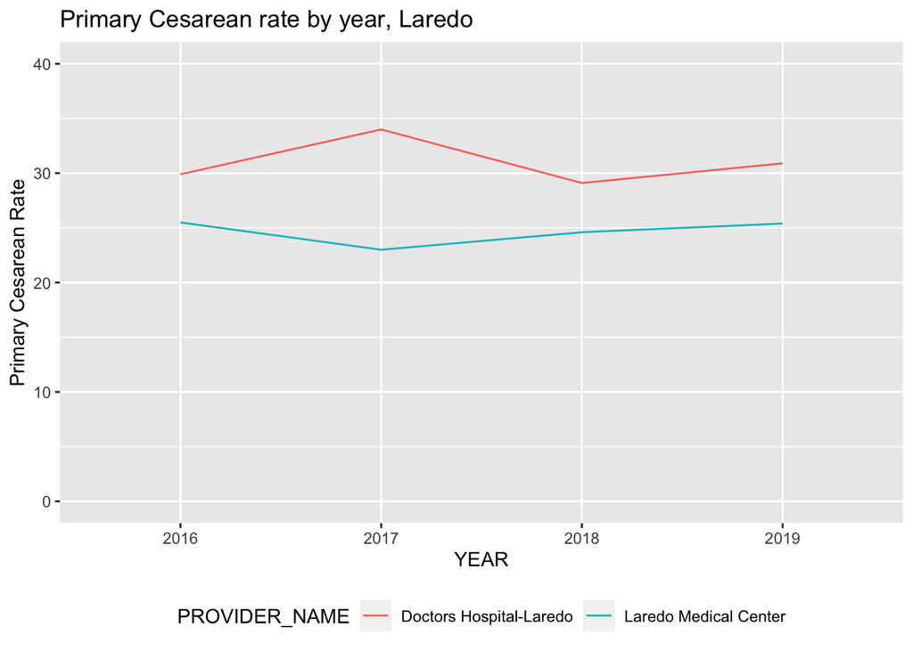

```r
pcsec_rate_yr_all %>%
  filter(str_detect(PROVIDER_NAME, "Laredo")) %>%
  ggplot(aes(YR, PCRATE)) +
  geom_line(aes(group = PROVIDER_NAME, color = PROVIDER_NAME)) +
  expand_limits(y = c(0,40)) +
  theme(legend.position="bottom", legend.box = "vertical") +
  labs(title = "Primary Cesarean rate by year, Laredo", x = "YEAR", y = "Primary Cesarean Rate")
```

### Chart: Primary Cesarean rates by quarter, Laredo

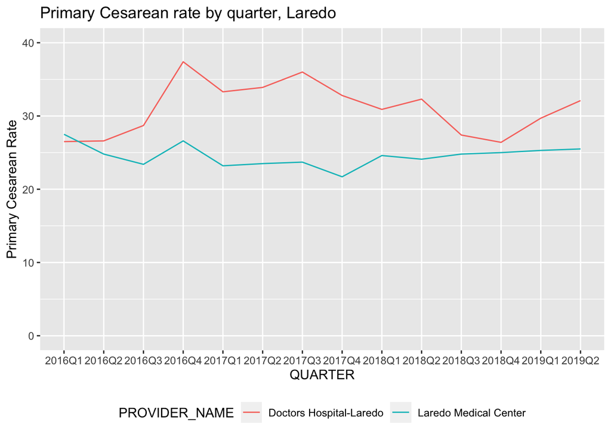

```r
pcsec_rate_qr_all <- del_pcsec %>%
  group_by(DISCHARGE, PROVIDER_NAME, PCSEC) %>%
  summarize(CNT = n()) %>%
  pivot_wider(names_from = PCSEC, values_from = CNT) %>%
  rename(
    NPCSEC_CNT = "FALSE",
    PCSEC_CNT = "TRUE"
  ) %>%
  mutate(
    TOTAL = NPCSEC_CNT + PCSEC_CNT
  ) %>%
  filter(TOTAL >= 100) %>%
  mutate(
    PCRATE = round((PCSEC_CNT / TOTAL) * 100,1)
  ) %>%
    arrange(PCRATE %>% desc())

pcsec_rate_qr_all %>%
  filter(str_detect(PROVIDER_NAME, "Laredo")) %>%
  ggplot(aes(DISCHARGE, PCRATE)) +
  geom_line(aes(group = PROVIDER_NAME, color = PROVIDER_NAME)) +
  expand_limits(y = c(0,40)) +
  theme(legend.position="bottom", legend.box = "vertical") +
  labs(title = "Primary Cesarean rate by quarter, Laredo", x = "QUARTER", y = "Primary Cesarean Rate")
```

## Write files

Writing some dataframes to rds for later use.

```r
# if (test_flag == F) del_pcsec %>% write_rds("data-processed/pcsec.rds")
# if (test_flag == F) pcsec_rate_yr_all %>% write_rds("data-processed/pcsec_rate_yr_all.rds")

# A klaxon to indicate the processing is complete
beepr::beep(4)
```